# 5_3_TSeriesDecomposition_Assignment_Homework

2/11/2022

# References

1. Hyndman, R.J., & Athanasopoulos, G., 2021. *Forecasting: principles and practice*. 3rd edition.

# Packages

```r
# Install these packages if you do not have them installed
install.packages("devtools")
devtools::install_github("FinYang/tsdl") # Bank of time-series data
```

```r
library(fpp3)
library(tsdl)
```

# Transformation assignment

For each of time series in this notebook, judge if one of the mathematical transformations explained in class is sensible or not.

If so, specify which transformation you have chosen and provide adequate justification

## Australian imports from Japan

```
## Plot variable not specified, automatically selected `.vars = aus_imports_japan`
```

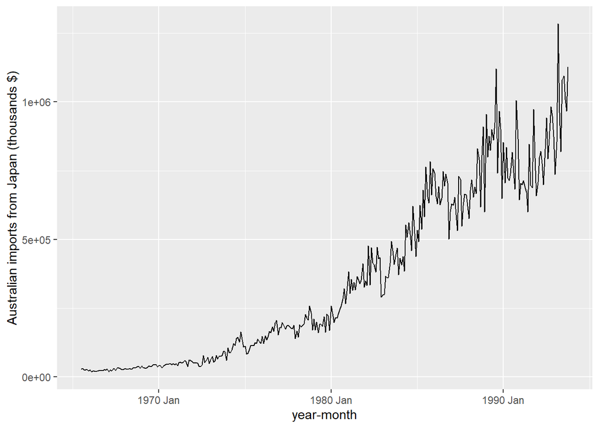

```r
start = yearmonth("1965 Jul")
end = yearmonth("1993 Oct")
y_m = seq(start, end, 1)

aus_import_japan <- tibble(aus_imports_japan = subset(tsdl, "Macroeconomic", 12)[[3]])
aus_import_japan <- aus_import_japan %>%
                      mutate(year_m = y_m) %>%
                      as_tsibble(index = year_m)

autoplot(aus_import_japan) +
labs(x = "year-month",
     y = "Australian imports from Japan (thousands $)")
```

By looking at the series, it appears that the amplitude of the oscillations is proportional to the level of the series.

```r
aus_import_japan %>%
  features(aus_import_japan, features = guerrero)
```

```
## # A tibble: 1 x 1
##   lambda_guerrero
##             <dbl>
## 1          0.0407
```

Guerreros feature is really close to 0. In this case we should therefore opt for a log transformation, which has much better intepretability than a box-cox transformation with the suggested lambda:

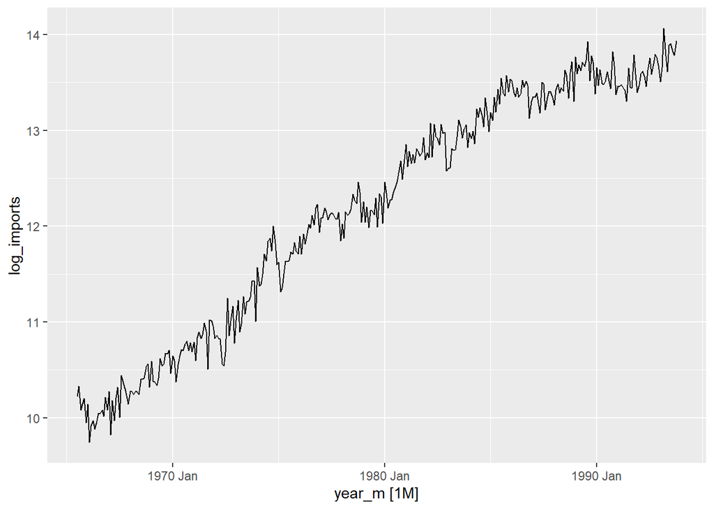

```r
aus_import_japan %>%
  mutate(log_imports = log(aus_imports_japan)) %>%
  autoplot(log_imports)
```

As we can see, the transformation has really evened out the oscillations.

## Private housing units started - USA

```
## Plot variable not specified, automatically selected `.vars = private_housing_Us`
```

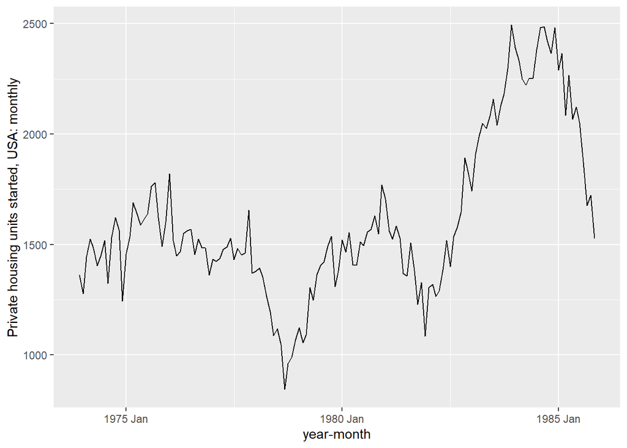

```r
start = yearmonth("1973 Dec")
end = yearmonth("1985 Nov")
y_m = seq(start, end, 1)

private_housing_Us <-  tibble(private_housing_Us = subset(tsdl, "Microeconomic", 12)[[2]])
private_housing_Us <- private_housing_Us %>%
                        mutate(year_m = y_m) %>%
                        as_tsibble(index = year_m)

autoplot(private_housing_Us) +
labs(x = "year-month",
     y = "Private housing units started, USA: monthly")
```

- The data does not appear to vary proportionally to the level of the series.
- There seem to be different periods in the time series.
- These issues are probably better resolved with modelling than with transformations.

If we cehck Guerreros feature and then perform a box-cox transformation we see that indeed it does not bring about much.

```r
lambda <- private_housing_Us %>%
  features(private_housing_Us, features = guerrero) %>%
  pull(lambda_guerrero)

lambda
```

```
## [1] 0.6053628
```

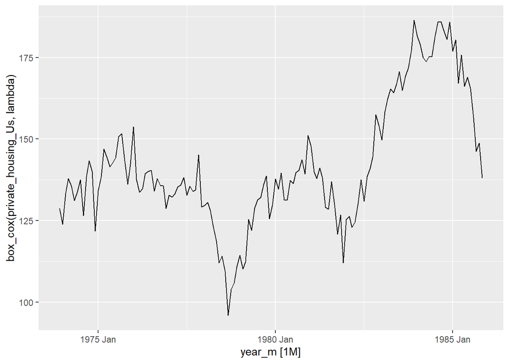

```r
private_housing_Us %>%
  autoplot(box_cox(private_housing_Us, lambda))
```

Another series where this occur is the Economy Passengers series between melbourne and Sydney

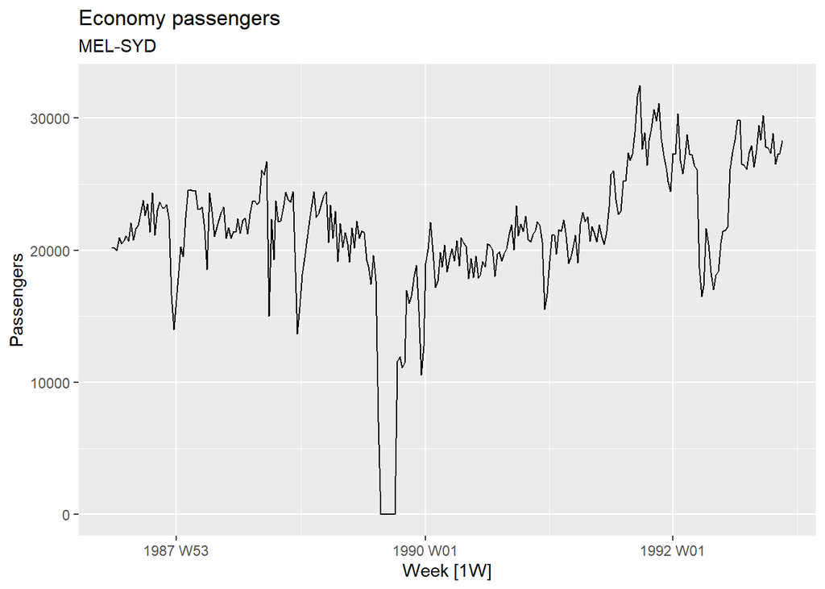

```r
ansett %>%
  filter(Airports == "MEL-SYD", Class == "Economy") %>%
  autoplot(Passengers) +
  labs(title = "Economy passengers", subtitle = "MEL-SYD")
```

Again:

- The data does not appear to vary proportionally to the level of the series.
- There seem to be different periods in the time series.
- These issues are probably better resolved with modelling than with transformations.